# Week 4: Differential expression across donors, and what the genes mean

Kevin Z. Lin

2026-08-15

> **A note on `cache = TRUE`, and on the `autodep` line next to it.** This document caches every chunk, so the first knit is slow and later ones take a couple of minutes. Two things are worth knowing before you rely on that.

> First, the disk cost: `knitr` re-saves every object a chunk *modifies*, and single-cell objects are large, so `_cache/` reaches gigabytes. Every chunk here whose only output is a figure is marked `cache=FALSE`, because a `ggplot` object stores the environment it was built in and caching one can drag a copy of the whole Seurat object onto disk with it. Exclude `_cache/` from Dropbox, OneDrive or Google Drive syncing, and delete it if a knit is interrupted — a truncated cache reappears on the next run as `error reading from connection`.

> Second, and more dangerous: **by default `knitr` caches each chunk independently and does not re-run a chunk when the objects it depends on change.** Edit an upstream chunk, re-knit, and a downstream figure can silently remain the *old* figure — a document whose text and plots disagree, with nothing to warn you. `autodep = TRUE` plus `knitr::dep_auto()` makes `knitr` track which chunks read which objects and invalidate accordingly. It is not perfect. Before anything leaves your hands, delete `_cache/` and knit once from clean.

# 1 Overview

This tutorial was made from the DESeq2 vignette, https://bioconductor.org/packages/release/bioc/vignettes/DESeq2/inst/doc/DESeq2.html, the `clusterProfiler` book, https://yulab-smu.top/biomedical-knowledge-mining-book/, and the pseudobulk section of the Harvard Chan Bioinformatics Core single-cell course. The diagnostic steps in between are the checks worth running before you trust any donor-level result.

The companion Week 4 tutorial clustered microglia and asked *what distinguishes one cluster from another*. This one asks a completely different question:

> **What is different between these people?**

Both questions are called “differential expression,” both are answered with a table of genes and p-values, and they are **not the same analysis**. Confusing them is the single most common error in this corner of the field, and it is the reason this session has two tutorials.

The difference is what counts as a replicate. When you ask what makes cluster 3 different from cluster 5, your replicates are cells, and you have thousands. When you ask what makes a donor with Alzheimer’s disease different from one without, your replicates are **donors**, and you have dozens at best. Testing that second question with cells as replicates treats 500 nuclei from one brain as 500 independent observations of that person’s biology. They are not — they came from one piece of tissue, processed in one library, from one individual. Do it anyway and you get p-values of `1e-80` for genes that would not survive a look at the donor-level averages.

The fix is **pseudobulk**: sum the counts across all cells of a given type within each donor, producing one profile per donor, then analyze that with the bulk RNA-seq tools that were built for exactly this design.

The plan:

| Stage | What it produces | Function |
| --- | --- | --- |
| 1. Pick a population and check it is testable | A cells-per-donor table you looked at before deciding | `table()` |
| 2. Aggregate | One column per donor, in raw counts | `AggregateExpression()` |
| 3. Filter | A gene universe chosen on expression, not on variability | `rowSums()` |
| 4. Check the design | A full-rank model matrix, verified | `model.matrix()`, `qr()` |
| 5. Look before testing | Sample-sample correlation, PCA on the pseudobulk | `vst()`, `plotPCA()` |
| 6. Test | Log fold changes and p-values per gene | `DESeq()`, `results()` |
| 7. Shrink | Fold changes you can rank | `lfcShrink()` |
| 8. Ask what the genes do | Enriched biological processes | `gseGO()` |

> **Where this sits in the workshop.** Week 1 ran a whole pipeline on defaults and defended nothing. Week 2 cleaned the data. Week 3 normalized it, picked genes, and did batch correction part one. This session is the payoff: the companion tutorial clusters and labels, and this one tests. Bulk deconvolution is **Week 5**.

# 2 Setting up

Everything here is on CRAN or Bioconductor. Install once, then leave these lines commented.

```r
# install.packages(c("Seurat", "ggplot2", "pheatmap", "RColorBrewer"))
# if (!require("BiocManager", quietly = TRUE)) install.packages("BiocManager")
# BiocManager::install(c("DESeq2", "apeglm", "EnhancedVolcano",
#                        "clusterProfiler", "org.Hs.eg.db", "enrichplot",
#                        "variancePartition"))
```

```r
library(Seurat)
library(SeuratObject)
library(DESeq2)
library(EnhancedVolcano)
library(clusterProfiler)
library(org.Hs.eg.db)
library(variancePartition)
library(ggplot2)
library(pheatmap)
```

```r
rm(list = ls())
```

# 3 The data

The dataset is a 40,000-nucleus microglia subset of **SEA-AD** (Seattle Alzheimer’s Disease Brain Cell Atlas), middle temporal gyrus, distributed as a Seurat object. The companion clustering tutorial describes it in full; here we need only three things from it — the raw counts, the donor each nucleus came from, and the donor’s neuropathology.

The file downloads itself into a temporary folder, so this tutorial runs as-is with nothing to set up. It is **525 MB**, so expect the first run to take a few minutes on a decent connection.

```r
data_dir <- tempdir(check = TRUE)

# If you have already downloaded seaad_microglia.RData, point data_dir at the
# folder holding it instead and the download below will be skipped, e.g.:
# data_dir <- "/path/to/your/data"
```

```r
options(timeout = 3600)

data_url <- paste0("https://www.dropbox.com/scl/fi/cei02rwh3gx61uu9zzeql/",
                   "seaad_microglia.RData",
                   "?rlkey=04erfwn3w2lrnr80pefwfh8fu&dl=1")
data_file <- file.path(data_dir, "seaad_microglia.RData")
expected_size <- 525672784

if (!file.exists(data_file) || file.size(data_file) != expected_size) {
  download.file(data_url, destfile = data_file, mode = "wb")
}

file.size(data_file) == expected_size
```

```
## [1] TRUE
```

> **Three details in that download, and every one of them has bitten someone.**

> **`options(timeout = 3600)`.** R’s default download timeout is **60 seconds**, which is not enough for half a gigabyte on any normal connection. Without this line the transfer dies partway through with `downloaded length 106201070 != reported length 525672784` — and because that arrives as a *warning* rather than an error, a script can sail past it and fail later at `load()` with a message about a corrupt file. This is the single most common reason a large `download.file()` “doesn’t work” in R.

> **`dl=1`, not `dl=0`.** Copying a Dropbox share link gives you `dl=0`, which serves the HTML preview page. You would download a web page, and `load()` would complain about a bad magic number.

> **`mode = "wb"`.** Forces a binary write. Without it the file is silently corrupted on Windows.

> The size comparison at the end is the point of all three: **verify the bytes you got are the bytes you wanted**, rather than trusting that no error appeared.

```r
load(data_file)
seurat_obj
```

```
## An object of class Seurat
## 36412 features across 40000 samples within 1 assay
## Active assay: RNA (36412 features, 0 variable features)
##  2 layers present: counts, data
##  2 dimensional reductions calculated: scVI, umap
```

> **`load()` is not `readRDS()`.** `load()` drops whatever objects the file happened to contain into your workspace under whatever names they were saved with, and it does **not** return a value — `x <- load("f.RData")` assigns a character vector of names, not your data, which is a genuinely confusing first encounter. Run `ls()` after every `load()` to see what you actually got, and prefer `saveRDS()` / `readRDS()` in your own work: those handle exactly one object and let *you* name it.

```r
ls()
```

```
## [1] "data_dir"      "data_file"     "data_url"      "expected_size"
## [5] "seurat_obj"
```

The metadata is where the clinical variables live. There are 43 columns; these are the ones this tutorial uses.

```r
head(seurat_obj@meta.data[, c("donor_id", "Supertype", "assay", "sex",
                              "ADNC", "APOE4.status", "Cognitive.status")])
```

```
##                                                  donor_id           Supertype
## GTTACAGGTGTAGTGG-L8TX_210513_01_C09-1142430429 H21.33.008   Micro-PVM_3-SEAAD
## GAATAGAAGCCGATTT-L8TX_210325_01_E07-1153814170 H21.33.014         Micro-PVM_2
## GTGACGCGTGTTTCTT-L8TX_210107_02_B12-1142430363 H20.33.015 Micro-PVM_2_3-SEAAD
## GTGAGGACAGCTGCCA-L8TX_210401_01_C09-1153814178 H21.33.011         Micro-PVM_2
## CCGGTGAGTTCAAGTC-L8TX_210826_01_B06-1153814368 H21.33.040         Micro-PVM_2
## CACAACAGTTCTGAGT-L8TX_210430_01_F04-1142430405 H20.33.040   Micro-PVM_3-SEAAD
##                                                    assay    sex         ADNC
## GTTACAGGTGTAGTGG-L8TX_210513_01_C09-1142430429 10x 3' v3 female         High
## GAATAGAAGCCGATTT-L8TX_210325_01_E07-1153814170 10x 3' v3   male Intermediate
## GTGACGCGTGTTTCTT-L8TX_210107_02_B12-1142430363 10x 3' v3   male Intermediate
## GTGAGGACAGCTGCCA-L8TX_210401_01_C09-1153814178 10x 3' v3 female       Not AD
## CCGGTGAGTTCAAGTC-L8TX_210826_01_B06-1153814368 10x 3' v3   male         High
## CACAACAGTTCTGAGT-L8TX_210430_01_F04-1142430405 10x 3' v3   male Intermediate
##                                                APOE4.status Cognitive.status
## GTTACAGGTGTAGTGG-L8TX_210513_01_C09-1142430429            N         Dementia
## GAATAGAAGCCGATTT-L8TX_210325_01_E07-1153814170            N      No dementia
## GTGACGCGTGTTTCTT-L8TX_210107_02_B12-1142430363            N         Dementia
## GTGAGGACAGCTGCCA-L8TX_210401_01_C09-1153814178            N      No dementia
## CCGGTGAGTTCAAGTC-L8TX_210826_01_B06-1153814368            Y      No dementia
## CACAACAGTTCTGAGT-L8TX_210430_01_F04-1142430405            N         Dementia
```

`ADNC` is the **Alzheimer’s Disease Neuropathologic Change** score — the autopsy-derived measure of how much AD pathology the brain actually had, on a four-level scale plus a `Reference` category for the neurotypical donors used to build the atlas.

```r
table(seurat_obj$ADNC)
```

```
##
##         High Intermediate          Low       Not AD    Reference
##        18778         9665         6428         4034         1095
```

```r
table(seurat_obj$assay)
```

```
##
##    10x 3' v3 10x multiome
##        35889         4111
```

## 3.1 Two subsets, both deliberate

```r
seurat_obj <- subset(seurat_obj,
                     ADNC %in% c("High", "Intermediate", "Low", "Not AD"))
seurat_obj <- subset(seurat_obj, assay == "10x 3' v3")
seurat_obj
```

```
## An object of class Seurat
## 36412 features across 34794 samples within 1 assay
## Active assay: RNA (36412 features, 0 variable features)
##  2 layers present: counts, data
##  2 dimensional reductions calculated: scVI, umap
```

The first line drops the `Reference` donors. They are a different cohort recruited under different criteria, and they have no ADNC score to compare — including them would mean silently comparing across studies.

The second line keeps a single chemistry. SEA-AD ran both 10x 3’ v3 and 10x multiome, and **27 donors appear in both**. If you aggregate by donor without splitting on assay, those donors get one profile that pools two different library preparations; if you split on both, they contribute twice and are no longer independent. Restricting to one chemistry avoids the question entirely, at the cost of some cells. Week 3’s integration material is about the other option.

```r
length(unique(seurat_obj$donor_id))
```

```
## [1] 84
```

# 4 Choosing a population to test

Pseudobulk is done **within a cell type**, not across all cells at once — the whole point is to ask whether microglia of a given state differ between donors, and averaging distinct states together would hide that. SEA-AD ships its own fine-grained labels in `Supertype`.

Before picking one, look at how many cells each donor contributes to each. This is the diagnostic that decides whether the analysis is possible at all, and it is worth running before you have any attachment to a particular comparison.

```r
cells_tab <- table(seurat_obj$Supertype, seurat_obj$donor_id)
dim(cells_tab)
```

```
## [1]  8 84
```

```r
apply(cells_tab, 1,
      function(x) c(donors_with_10_or_more = sum(x >= 10),
                    median_cells = median(x),
                    max_cells = max(x)))
```

```
##
##                          Micro-PVM_1 Micro-PVM_1_1-SEAAD Micro-PVM_2
##   donors_with_10_or_more          58                   3          83
##   median_cells                    14                   2         173
##   max_cells                       94                  14         853
##
##                          Micro-PVM_2_1-SEAAD Micro-PVM_2_2-SEAAD
##   donors_with_10_or_more                   7                  19
##   median_cells                             1                   5
##   max_cells                               46                 192
##
##                          Micro-PVM_2_3-SEAAD Micro-PVM_3-SEAAD
##   donors_with_10_or_more                  82                82
##   median_cells                            67                43
##   max_cells                              549               157
##
##                          Micro-PVM_4-SEAAD
##   donors_with_10_or_more                 5
##   median_cells                           1
##   max_cells                            185
```

Read that table as a feasibility check, not a summary. `Micro-PVM_2` is present in nearly every donor at a workable depth. `Micro-PVM_2_1-SEAAD` and `Micro-PVM_4-SEAAD` are present in a handful of donors at a median of one cell each — there is no donor-level comparison to be made there, and running DESeq2 on them would produce a table of numbers that mean nothing.

> **This is why you look first.** A pipeline that loops DESeq2 over every cluster will happily return results for the clusters that have no business being tested, and those results look exactly like the real ones. The cells-per-donor-per-cluster table is the cheapest guard against that, and it takes one line.

We take `Micro-PVM_2`.

```r
seurat_obj <- subset(seurat_obj, Supertype == "Micro-PVM_2")
seurat_obj
```

```
## An object of class Seurat
## 36412 features across 19130 samples within 1 assay
## Active assay: RNA (36412 features, 0 variable features)
##  2 layers present: counts, data
##  2 dimensional reductions calculated: scVI, umap
```

```r
summary(as.vector(table(seurat_obj$donor_id)))
```

```
##    Min. 1st Qu.  Median    Mean 3rd Qu.    Max.
##     2.0   115.8   173.0   227.7   304.2   853.0
```

# 5 Aggregating to pseudobulk

`AggregateExpression()` sums raw counts within each group. Passing several variables to `group.by` puts all of them in the resulting object’s metadata, which saves reassembling the donor table by hand.

```r
pseudo_seurat <- Seurat::AggregateExpression(
  seurat_obj,
  assays = "RNA",
  return.seurat = TRUE,
  group.by = c("donor_id", "APOE4.status", "ADNC", "sex"),
  verbose = FALSE)

pseudo_seurat
```

```
## An object of class Seurat
## 36412 features across 84 samples within 1 assay
## Active assay: RNA (36412 features, 0 variable features)
##  3 layers present: counts, data, scale.data
```

```r
head(pseudo_seurat@meta.data)
```

```
##                                                        orig.ident   donor_id
## H19.33.004_N_Not AD_female             H19.33.004_N_Not AD_female H19.33.004
## H20.33.001_N_Low_male                       H20.33.001_N_Low_male H20.33.001
## H20.33.002_N_Not AD_female             H20.33.002_N_Not AD_female H20.33.002
## H20.33.004_Y_High_male                     H20.33.004_Y_High_male H20.33.004
## H20.33.005_N_Intermediate_female H20.33.005_N_Intermediate_female H20.33.005
## H20.33.008_Y_High_female                 H20.33.008_Y_High_female H20.33.008
##                                  APOE4.status         ADNC    sex
## H19.33.004_N_Not AD_female                  N       Not AD female
## H20.33.001_N_Low_male                       N          Low   male
## H20.33.002_N_Not AD_female                  N       Not AD female
## H20.33.004_Y_High_male                      Y         High   male
## H20.33.005_N_Intermediate_female            N Intermediate female
## H20.33.008_Y_High_female                    Y         High female
```

One column per donor. Note what just happened to the size of the problem: tens of thousands of cells became 84 columns, and that number — not the cell count — is the sample size every p-value below is based on.

> **Sum, not mean.** `AggregateExpression()` defaults to summing counts, and that is what you want. DESeq2 models raw counts with a negative binomial and derives its own size factors; handing it averages, or normalized values, breaks the assumption it uses to estimate dispersion. If you take one thing from this section: pseudobulk means *sum the counts*, then let the bulk tool normalize.

Pull out the count matrix and the metadata.

```r
mat_pseudobulk <- SeuratObject::LayerData(pseudo_seurat,
                                          layer = "counts",
                                          assay = "RNA")
metadata_pseudobulk <- pseudo_seurat@meta.data

dim(mat_pseudobulk)
```

```
## [1] 36412    84
```

```r
mat_pseudobulk[1:5, 1:3]
```

```
## 5 x 3 sparse Matrix of class "dgCMatrix"
##          H19.33.004_N_Not AD_female H20.33.001_N_Low_male
## TSPAN6                            1                     1
## TNMD                              .                     .
## DPM1                            104                    66
## SCYL3                            67                    62
## C1orf112                        110                   131
##          H20.33.002_N_Not AD_female
## TSPAN6                            .
## TNMD                              .
## DPM1                             34
## SCYL3                            34
## C1orf112                         65
```

## 5.1 How many cells is each column made of?

A pseudobulk column built from 800 nuclei and one built from 2 nuclei are not comparable, and nothing downstream will tell you which is which. Record it.

```r
cells_per_donor <- table(seurat_obj$donor_id)
metadata_pseudobulk[, "n_cells"] <-
  as.vector(cells_per_donor[metadata_pseudobulk[, "donor_id"]])

summary(metadata_pseudobulk[, "n_cells"])
```

```
##    Min. 1st Qu.  Median    Mean 3rd Qu.    Max.
##     2.0   115.8   173.0   227.7   304.2   853.0
```

```r
sort(metadata_pseudobulk[, "n_cells"])[1:8]
```

```
## [1]  2 15 24 27 37 39 40 43
```

```r
min_cells <- 10
keep_samples <- metadata_pseudobulk[, "n_cells"] >= min_cells
sum(!keep_samples)
```

```
## [1] 1
```

```r
mat_pseudobulk <- mat_pseudobulk[, keep_samples]
metadata_pseudobulk <- metadata_pseudobulk[keep_samples, ]
dim(mat_pseudobulk)
```

```
## [1] 36412    83
```

`min_cells = 10` is a judgment call, not a standard. The point is that some threshold is needed and that yours should be stated.

## 5.2 Preparing the variables

DESeq2 needs the variables in the design to be factors, and for each factor it needs to know which level is the **reference** — the baseline that every other level is reported against. If you do not say, R takes the alphabetically first level.

```r
metadata_pseudobulk[, "sex"] <- factor(metadata_pseudobulk[, "sex"])
metadata_pseudobulk[, "APOE4.status"] <-
  factor(metadata_pseudobulk[, "APOE4.status"])

adnc_vec <- rep("NonAD", nrow(metadata_pseudobulk))
adnc_vec[metadata_pseudobulk[, "ADNC"] %in% c("High", "Intermediate")] <- "AD"
metadata_pseudobulk[, "ADNC"] <- relevel(factor(adnc_vec), ref = "NonAD")

summary(metadata_pseudobulk[, c("sex", "APOE4.status", "ADNC")])
```

```
##      sex     APOE4.status    ADNC
##  female:50   N:59         NonAD:21
##  male  :33   Y:24         AD   :62
```

> **Why the reference level matters: it decides the direction, not the statistics.** For a two-level factor the fit is symmetric. Swap the reference and DESeq2 estimates the same dispersions, the same Wald statistic up to sign, and **identical p-values**. What changes is which way round the comparison is reported. Our two levels are `AD` and `NonAD`, and `AD` sorts first alphabetically — so without the `relevel()` above, DESeq2 would treat AD as the baseline and give you a coefficient named `ADNC_NonAD_vs_AD`. Every `log2FoldChange` in this tutorial would then carry the opposite sign: the right-hand side of the volcano plot would be genes higher in *controls*, the “upregulated in AD” list would be the downregulated one, and the GSEA at the end — which ranks genes by the signed Wald statistic — would report every pathway with its enrichment score flipped. Nothing errors, no number looks wrong, and the biology you write down is backwards. So the answer to “why does it matter if it is not the one I meant” is: it matters entirely for interpretation, and interpretation is the whole output.

> Two consequences. First, the fix is not to remember which level sorts first — it is to set the reference on purpose and then **read `resultsNames()`** after fitting, which spells the comparison out as `variable_level_vs_reference`. We do that below. Second, with more than two levels the reference does more than set a sign: it decides which contrasts exist as coefficients at all. With `Not AD` as the reference you get `High vs Not AD`, `Low vs Not AD` and so on, and `High vs Low` is not among them — you would have to request it explicitly with `results(dds, contrast = c("ADNC", "High", "Low"))`.

Collapsing four ADNC levels into two is a modelling decision with consequences: it buys power and a fold change that is easy to describe, and it throws away the ordering. `Low` and `Not AD` become the same thing; so do `High` and `Intermediate`. An ordinal model, or ADNC as a numeric trend, is the alternative and is not obviously worse.

## 5.3 Check the alignment before you trust it

DESeq2 matches columns of the count matrix to rows of the metadata **by position**, not by name. If they ever fall out of order, every result is wrong and nothing errors.

```r
all(colnames(mat_pseudobulk) == rownames(metadata_pseudobulk))
```

```
## [1] TRUE
```

> **The check that has to be there.** Print a sample-order confirmation before every DE run — it costs one line, and this is why. A mis-joined metadata table produces a complete, plausible, entirely fictional result set. There is no downstream symptom.

# 6 Choosing which genes to test

The tempting shortcut here is to reuse the 2,000 variable genes the clustering workflow already selected. They are sitting right there in the object, and testing 2,000 genes instead of 15,000 is faster and gives a gentler multiple- testing correction. It is a trap, and it is worth naming.

> **Do not select genes on variability and then test them for differential expression.** `FindVariableFeatures()` ranks genes by how much they vary *across cells* — which includes the between-donor variation you are about to test. Choosing the top 2,000 on that criterion and then asking which of them differ between donor groups is selecting on the outcome. It also silently redefines the multiple-testing universe: your FDR is now computed over a set that was already enriched for what you are looking for.

Filter on **detection** instead, which is orthogonal to the contrast: keep genes seen in a reasonable number of donors. The equivalent filter can also be applied at the single-cell level before aggregating.

```r
min_samples <- ceiling(0.25 * ncol(mat_pseudobulk))
min_samples
```

```
## [1] 21
```

```r
genes_detected <- Matrix::rowSums(mat_pseudobulk >= 5) >= min_samples
sum(genes_detected)
```

```
## [1] 15420
```

```r
mat_pseudobulk <- mat_pseudobulk[genes_detected, ]
dim(mat_pseudobulk)
```

```
## [1] 15420    83
```

# 7 The design

```r
design_formula <- ~ sex + APOE4.status + ADNC
design_mat <- model.matrix(design_formula, metadata_pseudobulk)

colnames(design_mat)
```

```
## [1] "(Intercept)"   "sexmale"       "APOE4.statusY" "ADNCAD"
```

```r
dim(design_mat)
```

```
## [1] 83  4
```

`ADNC` is the contrast of interest; `sex` and `APOE4.status` are in the model to be adjusted for. Everything in the formula that is not the term you read out is a covariate, and adding covariates costs degrees of freedom — with 80-odd donors that is affordable, with 8 it is not.

A design matrix that is not full rank makes DESeq2 fail, or worse, silently estimate something other than what you wrote. Check it.

```r
qr(design_mat)$rank
```

```
## [1] 4
```

```r
ncol(design_mat)
```

```
## [1] 4
```

```r
qr(design_mat)$rank == ncol(design_mat)
```

```
## [1] TRUE
```

> **Do not “fix” this automatically.** The obvious repair is to drop design columns in a loop until the matrix inverts, and it is a repair you will find written into pipelines because it keeps them running on small unbalanced cohorts. The cost is that the model which was fitted is no longer the model that was specified, and unless the code says which columns it dropped, nothing in the output tells you that happened — you get a clean table of results for a question you did not ask. If your design is not full rank, the honest responses are to drop a covariate on purpose, collapse a level, or accept that the comparison is not identifiable in your data.

Full rank is a low bar, though. It says the coefficients are *identifiable*, not that they are estimated from a balanced comparison. Cross-tabulate the covariates against the contrast and look at the cells:

```r
table(metadata_pseudobulk[, "ADNC"], metadata_pseudobulk[, "sex"])
```

```
##
##         female male
##   NonAD     12    9
##   AD        38   24
```

```r
table(metadata_pseudobulk[, "ADNC"], metadata_pseudobulk[, "APOE4.status"])
```

```
##
##          N  Y
##   NonAD 21  0
##   AD    38 24
```

> **Read that second table before reading any APOE4 result.** Every APOE4-positive donor in this cohort is in the AD group; the non-AD group is entirely APOE4-negative. The design is still full rank — the AD group contains both genotypes, so the coefficient is estimable — but it is estimated **only from the within-AD contrast**. This is not a bug in the data; it is what APOE4 does, since carrying the allele is a major risk factor for having AD pathology at autopsy. It does mean that “adjusting for APOE4 status” here is doing something narrower than it sounds, and that a headline APOE4 effect from this design would need to be described very carefully. A design matrix check would not have caught it. A two-way table did.

# 8 Looking at the data before testing it

```r
dds <- DESeq2::DESeqDataSetFromMatrix(countData = mat_pseudobulk,
                                      colData = metadata_pseudobulk,
                                      design = design_formula)
dds
```

```
## class: DESeqDataSet
## dim: 15420 83
## metadata(1): version
## assays(1): counts
## rownames(15420): DPM1 SCYL3 ... PRRC2B F8A1
## rowData names(0):
## colnames(83): H19.33.004_N_Not AD_female H20.33.001_N_Low_male ...
##   H21.33.046_N_High_male H21.33.047_N_Intermediate_male
## colData names(6): orig.ident donor_id ... sex n_cells
```

## 8.1 Why the counts need transforming first

Every plot in this section is really a statement about **distance between donors** — a correlation, a PCA. Distances are only meaningful if every gene gets a comparable say in them, and on the raw count scale they do not. Count data is heteroskedastic: a gene averaging 5,000 counts has a variance in the thousands, a gene averaging 5 counts has a variance around 5. Correlate two donors on raw counts and the answer is decided almost entirely by the few hundred loudest genes.

The obvious fix, `log(x + 1)`, overcorrects at the other end. Down where a gene has 1 count in one donor and 4 in another, that is pure sampling noise, but on the log scale it is a two-fold change — as large a move as anything the highly expressed genes make. Log-transformed data is dominated by its quietest, least reliable genes.

A **variance-stabilizing transform** fits the actual mean–variance relationship in *your* data and applies the transformation that flattens it, so that variance is roughly constant across the whole expression range. High-count genes get compressed, low-count genes get shrunk toward the gene’s overall mean rather than inflated. After it, a difference of 0.5 means about the same amount of evidence whether the gene is loud or quiet, and a correlation between two donors is a statement about their transcriptomes rather than about their sequencing depth.

`vst()` and `rlog()` are DESeq2’s two implementations of that idea and are interchangeable in what they are for. `vst()` fits a parametric curve to the dispersion trend and is fast; `rlog()` shrinks each gene individually and handles small experiments and wildly varying library sizes better, at a cost that grows badly with sample size. DESeq2’s own advice is `rlog()` below roughly 30 samples and `vst()` above, and we have 83.

```r
vsd <- DESeq2::vst(dds, blind = TRUE)
```

`blind = TRUE` matters: it tells the transform to ignore the design, so the picture you are about to look at is not shaped by the hypothesis you are about to test.

## 8.2 What to look for in the correlation heatmap

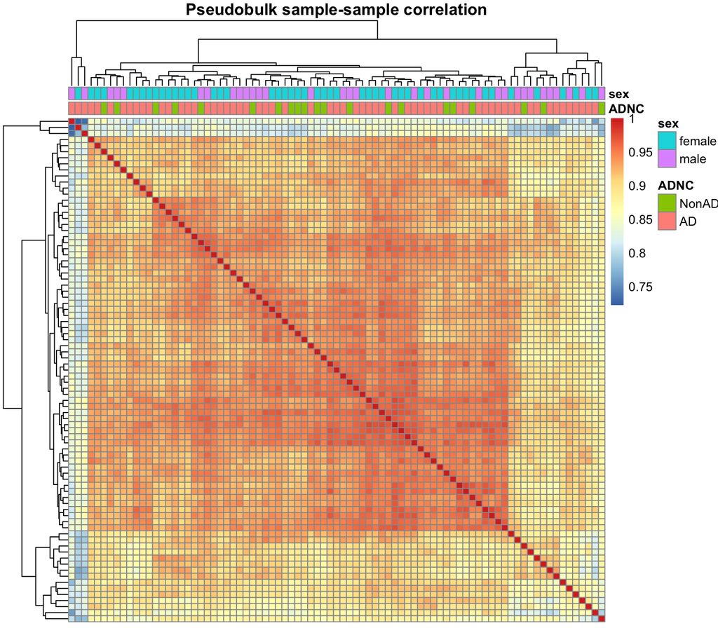

```r
vsd_mat <- SummarizedExperiment::assay(vsd)
cor_mat <- cor(vsd_mat)

annotation_df <- data.frame(ADNC = metadata_pseudobulk[, "ADNC"],
                            sex = metadata_pseudobulk[, "sex"],
                            row.names = rownames(metadata_pseudobulk))

pheatmap::pheatmap(cor_mat,
                   annotation_col = annotation_df,
                   show_rownames = FALSE,
                   show_colnames = FALSE,
                   main = "Pseudobulk sample-sample correlation")
```

An 80 × 80 grid of colour is not something to judge by eye, so put numbers on the same questions first.

```r
cor_offdiag <- cor_mat[lower.tri(cor_mat)]
round(quantile(cor_offdiag, c(0, 0.05, 0.5, 0.95, 1)), 3)
```

```
##    0%    5%   50%   95%  100%
## 0.722 0.837 0.922 0.959 0.977
```

```r
mean_cor <- (rowSums(cor_mat) - 1) / (ncol(cor_mat) - 1)
round(sort(mean_cor)[1:5], 3)
```

```
##       H20.33.037_N_High_female         H21.33.020_N_High_male
##                          0.826                          0.828
## H20.33.024_N_Intermediate_male       H20.33.038_N_High_female
##                          0.828                          0.860
##          H21.33.019_N_Low_male
##                          0.865
```

```r
metadata_pseudobulk[names(sort(mean_cor)[1:5]), "n_cells"]
```

```
## [1] 15 24 27 40 39
```

```r
cor(mean_cor, log10(metadata_pseudobulk[, "n_cells"]))
```

```
## [1] 0.7756242
```

Now the plot. There are four things worth looking for in it, and the reason to name them is that a heatmap like this gets printed far more often than it gets read.

**One: the overall level.** Every column is the same cell type from the same brain region, so these profiles ought to be very similar to one another, and they are — the middle 90% of the off-diagonal correlations run from 0.84 to 0.96. A version of this plot centred on 0.3 would not be telling you which donors differ; it would be telling you something broke upstream. This is a *did anything go wrong* plot before it is anything else.

**Two: individual samples that sit apart from everything.** These are what the plot is best at. Look for a row and column that is uniformly cooler than the rest of the grid, rather than for pairs — a donor that correlates poorly with the whole cohort is a candidate to exclude; two donors that correlate poorly with each other but fine with everyone else are just two donors. Three samples on the left edge of this grid stand off from the rest, and `mean_cor` gives you their names — around 0.83 average correlation against a cohort median of 0.92 — instead of making you count squares. Finding them now matters because DESeq2 will not mention them later: it estimates one dispersion per gene pooled across all donors, so an aberrant donor widens that estimate and quietly costs power for every gene in the experiment.

**Three: whether the block structure lines up with the annotation bars.** This is the one people expect to be the payoff, and it usually is not. If AD and non-AD pseudobulk profiles were fundamentally different, the `ADNC` bar would sort into two blocks along the dendrogram. It does not — the green and red squares are interleaved all the way across, and so are the sexes. That is the ordinary outcome for a disease contrast in brain tissue, and it is worth absorbing before reading a single p-value: whatever separates these donors most strongly, disease status is not it. The variance decomposition at the end of this tutorial puts a number on that; the heatmap gets you there for free in one line.

**Four: whether it lines up with something you did not want.** The structure that *is* here — a dense, highly correlated core with paler samples trailing off it — has to come from somewhere, and the usual suspects are technical: sequencing depth, cells per donor, batch, PMI, RNA quality. Correlating each donor’s average correlation against its cell count is the cheap version of that check, and here it comes back at **0.78**. That is the honest reading of this heatmap: it is substantially a picture of how many nuclei each donor contributed. The three samples flagged above are the three thinnest in the cohort, and a donor built from few nuclei is *noisy*, not *strange* — which changes what you would do about it, since excluding it is a decision about precision rather than about sample quality.

> **Low correlation and outlying position are not the same thing.** PC1 of the same matrix, two plots down, correlates with that same cell count at only 0.19. There is no contradiction: sampling noise from a thin pseudobulk column is spread across all genes at once, which pulls that sample away from *everything* without pushing it in any particular direction. A correlation heatmap sees that and a PCA largely does not. It is a decent argument for looking at both, which is what the next two plots are for.

## 8.3 The same questions, in a PCA

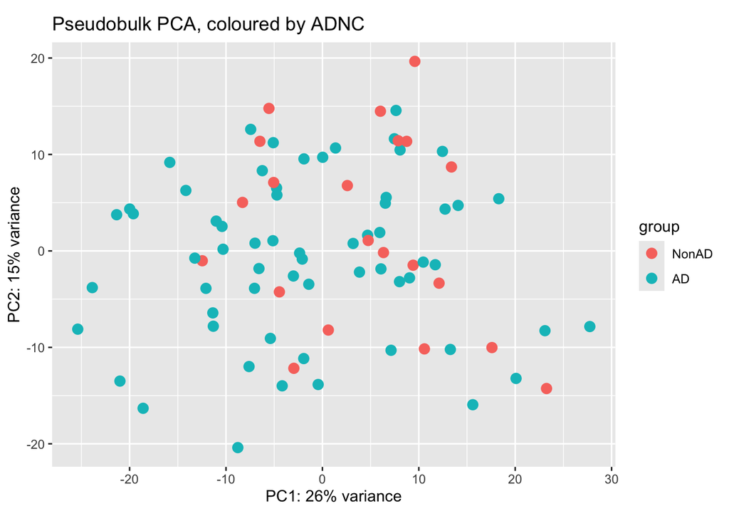

```r
gg <- DESeq2::plotPCA(vsd, intgroup = "ADNC") +
  ggplot2::ggtitle("Pseudobulk PCA, coloured by ADNC")
plot(gg)
```

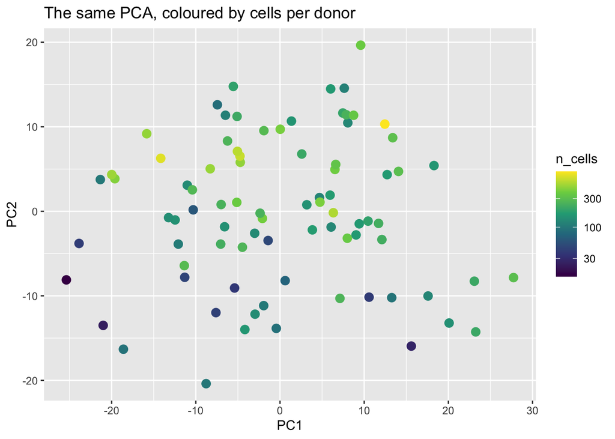

```r
pca_df <- DESeq2::plotPCA(vsd, intgroup = "ADNC", returnData = TRUE)
pca_df[, "n_cells"] <- metadata_pseudobulk[, "n_cells"]

gg <- ggplot2::ggplot(pca_df, ggplot2::aes(x = PC1, y = PC2)) +
  ggplot2::geom_point(ggplot2::aes(colour = n_cells), size = 3) +
  ggplot2::scale_colour_viridis_c(trans = "log10") +
  ggplot2::ggtitle("The same PCA, coloured by cells per donor")
plot(gg)
```

Those two plots are the same points twice, and comparing them is the point: if donors separate by how many cells they contributed rather than by their pathology, the leading variation in your pseudobulk is a depth artifact and the gene list will be about depth too.

Do not settle it by eye. Correlate the components against both.

```r
cor(pca_df[, "PC1"], log10(pca_df[, "n_cells"]))
```

```
## [1] 0.1932501
```

```r
cor(pca_df[, "PC2"], log10(pca_df[, "n_cells"]))
```

```
## [1] 0.5024462
```

```r
summary(aov(pca_df[, "PC1"] ~ metadata_pseudobulk[, "ADNC"]))
```

```
##                               Df Sum Sq Mean Sq F value Pr(>F)
## metadata_pseudobulk[, "ADNC"]  1    489   488.7    3.76  0.056 .
## Residuals                     81  10529   130.0
## ---
## Signif. codes:  0 '***' 0.001 '**' 0.01 '*' 0.05 '.' 0.1 ' ' 1
```

Here PC1 correlates with depth at 0.19 and separates the ADNC groups at `p = 0.056` — so neither the artifact nor the biology dominates the leading component. That is a mildly reassuring answer, and the reason to run the check is that the alternative answers are the ones that would have changed what you do next.

# 9 Testing

```r
dds <- DESeq2::DESeq(dds)
DESeq2::resultsNames(dds)
```

```
## [1] "Intercept"           "sex_male_vs_female"  "APOE4.status_Y_vs_N"
## [4] "ADNC_AD_vs_NonAD"
```

`resultsNames()` is worth reading rather than assuming. Each name is a coefficient in the fitted model, and the one you want is spelled out in `variable_level_vs_reference` form — evidence that `relevel()` did what you intended.

```r
deseq2_res <- DESeq2::results(dds, name = "ADNC_AD_vs_NonAD")
summary(deseq2_res)
```

```
##
## out of 15420 with nonzero total read count
## adjusted p-value < 0.1
## LFC > 0 (up)       : 35, 0.23%
## LFC < 0 (down)     : 15, 0.097%
## outliers [1]       : 0, 0%
## low counts [2]     : 11958, 78%
## (mean count < 65)
## [1] see 'cooksCutoff' argument of ?results
## [2] see 'independentFiltering' argument of ?results
```

```r
deseq2_res_ordered <- deseq2_res[order(deseq2_res$padj), ]
head(as.data.frame(deseq2_res_ordered), 10)
```

```
##                  baseMean log2FoldChange     lfcSE      stat       pvalue
## MT-ND3           474.2273      1.9081564 0.4266909  4.471987 7.749599e-06
## MT-ATP6          387.1918      1.7216517 0.3802169  4.528077 5.952281e-06
## ENSG00000286044  101.6465      1.9028429 0.4336104  4.388370 1.142034e-05
## TLN2             378.2042     -0.4293441 0.1043558 -4.114233 3.884687e-05
## MT-CO2           435.4273      1.3819516 0.3339251  4.138507 3.495728e-05
## MT-CYB           303.1090      1.5062340 0.3554041  4.238089 2.254308e-05
## MT-ND4           341.7900      1.5502885 0.3709022  4.179777 2.917948e-05
## MT-ND1           183.2301      1.4490168 0.3468804  4.177281 2.950149e-05
## FKBP5           1962.1782      0.7211605 0.1793918  4.020030 5.819072e-05
## MT-ND2           186.2780      1.2839437 0.3184528  4.031817 5.534718e-05
##                       padj
## MT-ND3          0.01317907
## MT-ATP6         0.01317907
## ENSG00000286044 0.01317907
## TLN2            0.01681098
## MT-CO2          0.01681098
## MT-CYB          0.01681098
## MT-ND4          0.01681098
## MT-ND1          0.01681098
## FKBP5           0.02014563
## MT-ND2          0.02014563
```

## 9.1 Shrinking the fold changes

A gene with few counts can post a huge fold change on almost no evidence: 3 counts in the non-AD donors against 30 in the AD donors is a ten-fold change, and it is also nothing at all. Ranking by raw `log2FoldChange` puts genes like that at the top of the table, above genes measured in the thousands that moved by a solid and believable 40%.

`lfcShrink()` is the standard answer to that. It fits a prior to the distribution of effect sizes across all genes and reports each gene’s fold change under that prior. A gene with thousands of counts has a tight likelihood and barely moves; a gene with a handful has a wide one and gets pulled toward zero, because the data never had much to say about it. `type = "apeglm"` is the current recommended estimator; note it requires `coef =` naming a coefficient from `resultsNames()` and will not take an arbitrary `contrast =`.

```r
deseq2_shrunk <- DESeq2::lfcShrink(dds,
                                   coef = "ADNC_AD_vs_NonAD",
                                   type = "apeglm")
head(as.data.frame(deseq2_shrunk[order(deseq2_shrunk$padj), ]), 10)
```

```
##                  baseMean log2FoldChange      lfcSE       pvalue       padj
## MT-ND3           474.2273    1.687090894 0.47034635 7.749599e-06 0.01317907
## MT-ATP6          387.1918    1.526411336 0.41775829 5.952281e-06 0.01317907
## ENSG00000286044  101.6465    0.002850012 0.03703201 1.142034e-05 0.01317907
## TLN2             378.2042   -0.359358541 0.11306867 3.884687e-05 0.01681098
## MT-CO2           435.4273    1.191697218 0.37405284 3.495728e-05 0.01681098
## MT-CYB           303.1090    1.306758087 0.39730668 2.254308e-05 0.01681098
## MT-ND4           341.7900    1.333977978 0.41534732 2.917948e-05 0.01681098
## MT-ND1           183.2301    1.251492190 0.38860636 2.950149e-05 0.01681098
## FKBP5           1962.1782    0.616476086 0.19978974 5.819072e-05 0.02014563
## MT-ND2           186.2780    1.095255424 0.35913817 5.534718e-05 0.02014563
```

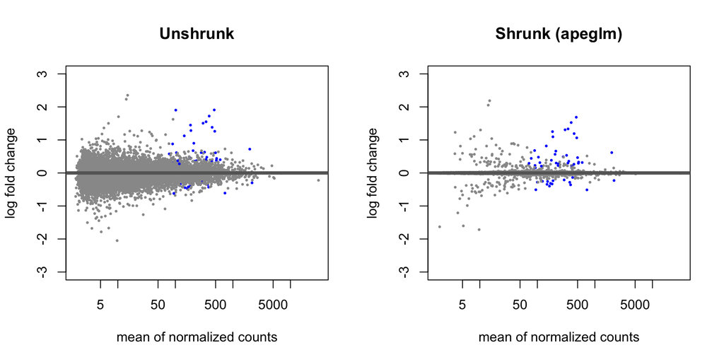

```r
par(mfrow = c(1, 2))
DESeq2::plotMA(deseq2_res, ylim = c(-3, 3), main = "Unshrunk")
DESeq2::plotMA(deseq2_shrunk, ylim = c(-3, 3), main = "Shrunk (apeglm)")
```

```r
par(mfrow = c(1, 1))
```

The two panels are the same genes, and the difference between them is the whole point. On the left, the low-count end of the axis is a wide fan: genes averaging 5 to 50 counts reaching a log2 fold change of ±2, none of them significant, all of them ahead of the real hits if you sort by effect size. On the right that fan has collapsed onto the zero line, while the blue significant genes — which sit at means of a few hundred — have barely moved.

> **Yes, this is standard, and if you have not seen it, here is the likely reason.** Shrunken fold changes are what the DESeq2 vignette recommends for MA plots, volcano plots, and any ranking or thresholding of genes by effect size. They used to be automatic: until DESeq2 1.16, `results()` applied the shrinkage itself by default (`betaPrior = TRUE`), so a great deal of published work and a great many older tutorials report shrunken fold changes without ever mentioning it. That default was pulled out into a separate `lfcShrink()` call so that the *estimate* you report and the *test* you report stay visibly separate steps — which is clearer, at the cost that you now have to know the step exists. Reporting unshrunk fold changes is not an error, and plenty of papers do; it just means a six-fold change in your table may be one lightly-observed gene.

The p-values are identical between the two — shrinkage changes the effect size estimate, not the test. Use the unshrunk table to decide *what is significant*, and the shrunk one to decide *what is large*. That division is also why the GSEA at the end of this tutorial ranks on the Wald statistic from the unshrunk results: the statistic already carries the same information shrinkage adds, in that it divides each fold change by its own standard error.

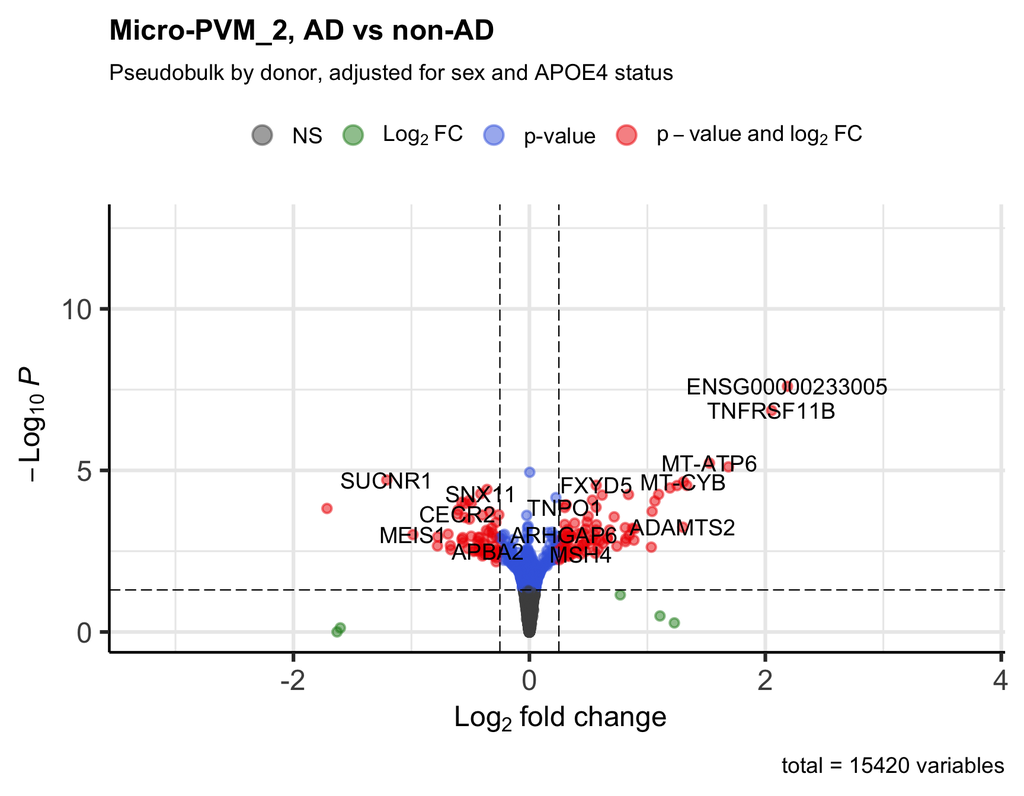

```r
gg <- EnhancedVolcano::EnhancedVolcano(
  deseq2_shrunk,
  lab = rownames(deseq2_shrunk),
  x = "log2FoldChange",
  y = "pvalue",
  pCutoff = 0.05,
  FCcutoff = 0.25,
  title = "Micro-PVM_2, AD vs non-AD",
  subtitle = "Pseudobulk by donor, adjusted for sex and APOE4 status")
plot(gg)
```

> **The volcano’s y-axis is the raw p-value, and its cutoff line is drawn at a raw p-value too.** That is the package default and it is not the threshold you should report. Read significance off `padj`.

# 10 Interrogating the answer

You now have a ranked gene list, and the temptation is to go straight from here to a volcano plot to a slide. **The step that gets skipped is reading the gene names.** It is easy to skip precisely because nothing prompts you to do it: the table is sorted, the p-values are small, the volcano looks like a volcano, and the output of `results()` gives no sign that anything is amiss. Sorting a column is not the same as looking at what is in it. So before this becomes a figure, read the top twenty genes and ask whether they have something in common that has nothing to do with your hypothesis.

```r
top_genes <- rownames(deseq2_res_ordered)[1:20]
top_genes
```

```
##  [1] "MT-ND3"          "MT-ATP6"         "ENSG00000286044" "TLN2"
##  [5] "MT-CO2"          "MT-CYB"          "MT-ND4"          "MT-ND1"
##  [9] "FKBP5"           "MT-ND2"          "CNTRL"           "STARD13"
## [13] "PRKCA"           "MT-CO3"          "NUDT16-DT"       "TNPO1"
## [17] "TXNIP"           "RASA3"           "ARHGAP17"        "IL6R"
```

```r
sum(grepl("^MT-", top_genes))
```

```
## [1] 8
```

Seven of the top ten genes, and eight of the top twenty, are mitochondrial. That should stop you, because **these are nuclei**. A nucleus does not contain mitochondria, so mitochondrial transcripts in a snRNA-seq count matrix are ambient RNA — soup from lysed cells captured alongside the nucleus. Week 2 made this point in the other direction — the ambient contamination fraction in nuclei can be *estimated from* the mitochondrial genes, precisely because their true expression is known to be zero.

So the strongest “AD versus non-AD” signal in this analysis is a candidate artifact: if AD samples carry more ambient RNA — because of tissue quality, PMI, dissociation, or anything else that differs systematically — then every mitochondrial gene will come out higher in AD, with no biology involved.

Test it directly. The mitochondrial fraction is a per-donor quantity, so compute it on the pseudobulk.

```r
mito_genes <- grep("^MT-", rownames(mat_pseudobulk), value = TRUE)
mito_genes
```

```
##  [1] "MT-ND6"  "MT-CO2"  "MT-CYB"  "MT-ND2"  "MT-ND5"  "MT-CO1"  "MT-ND3"
##  [8] "MT-ND4"  "MT-ND1"  "MT-ATP6" "MT-CO3"  "MT-ND4L" "MT-ATP8"
```

```r
mito_fraction <- Matrix::colSums(mat_pseudobulk[mito_genes, ]) /
  Matrix::colSums(mat_pseudobulk)
metadata_pseudobulk[, "mito_fraction"] <- mito_fraction

summary(mito_fraction)
```

```
##      Min.   1st Qu.    Median      Mean   3rd Qu.      Max.
## 0.0001979 0.0010146 0.0018528 0.0030896 0.0033803 0.0142025
```

```r
tapply(mito_fraction, metadata_pseudobulk[, "ADNC"], summary)
```

```
## $NonAD
##      Min.   1st Qu.    Median      Mean   3rd Qu.      Max.
## 0.0001979 0.0007932 0.0011510 0.0013718 0.0019035 0.0031476
##
## $AD
##      Min.   1st Qu.    Median      Mean   3rd Qu.      Max.
## 0.0002684 0.0011629 0.0020946 0.0036715 0.0047447 0.0142025
```

```r
wilcox.test(mito_fraction ~ metadata_pseudobulk[, "ADNC"])
```

```
##
##  Wilcoxon rank sum test with continuity correction
##
## data:  mito_fraction by metadata_pseudobulk[, "ADNC"]
## W = 371, p-value = 0.003415
## alternative hypothesis: true location shift is not equal to 0
```

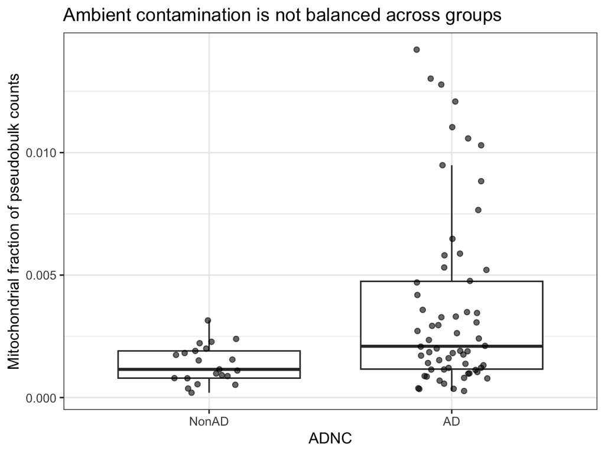

```r
plot_df <- data.frame(mito_fraction = mito_fraction,
                      ADNC = metadata_pseudobulk[, "ADNC"])

gg <- ggplot2::ggplot(plot_df,
                      ggplot2::aes(x = ADNC, y = mito_fraction)) +
  ggplot2::geom_boxplot(outlier.shape = NA) +
  ggplot2::geom_jitter(width = 0.15, alpha = 0.6) +
  ggplot2::labs(y = "Mitochondrial fraction of pseudobulk counts",
                title = "Ambient contamination is not balanced across groups") +
  ggplot2::theme_bw()
plot(gg)
```

The contamination is real and it is not balanced: the AD group’s median mitochondrial fraction is roughly double the non-AD group’s (0.21% against 0.12%), and the difference survives a rank test at `p = 0.003`.

The plot adds something the medians do not. The two groups overlap almost completely at the bottom; what separates them is a **tail of about a dozen AD donors** running up to 1.4%, with no non-AD counterpart above 0.32%. So this is not “AD samples are uniformly dirtier” — it is a subset of AD samples that are, and they are enough to move a group mean. That distinction matters for what you would do about it: a covariate treats it as a smooth gradient, whereas the picture suggests a handful of samples you might simply exclude and re-run.

Put it in the model as a covariate and re-test.

```r
dds_adj <- DESeq2::DESeqDataSetFromMatrix(
  countData = mat_pseudobulk,
  colData = metadata_pseudobulk,
  design = ~ sex + APOE4.status + mito_fraction + ADNC)

dds_adj <- DESeq2::DESeq(dds_adj)
DESeq2::resultsNames(dds_adj)
```

```
## [1] "Intercept"           "sex_male_vs_female"  "APOE4.status_Y_vs_N"
## [4] "mito_fraction"       "ADNC_AD_vs_NonAD"
```

```r
deseq2_res_adj <- DESeq2::results(dds_adj, name = "ADNC_AD_vs_NonAD")
summary(deseq2_res_adj)
```

```
##
## out of 15420 with nonzero total read count
## adjusted p-value < 0.1
## LFC > 0 (up)       : 11, 0.071%
## LFC < 0 (down)     : 3, 0.019%
## outliers [1]       : 0, 0%
## low counts [2]     : 13752, 89%
## (mean count < 142)
## [1] see 'cooksCutoff' argument of ?results
## [2] see 'independentFiltering' argument of ?results
```

```r
deseq2_res_adj_ordered <- deseq2_res_adj[order(deseq2_res_adj$padj), ]
head(as.data.frame(deseq2_res_adj_ordered), 10)
```

```
##          baseMean log2FoldChange     lfcSE      stat       pvalue       padj
## MT-ND3   474.2273      1.7420550 0.4292232  4.058623 4.936303e-05 0.04116876
## MT-ATP6  387.1918      1.5481858 0.3772501  4.103871 4.062943e-05 0.04116876
## MT-CO2   435.4273      1.2216101 0.3209368  3.806388 1.410109e-04 0.04704123
## MT-CYB   303.1090      1.3417235 0.3499934  3.833568 1.262977e-04 0.04704123
## MT-ND1   183.2301      1.2865031 0.3344618  3.846487 1.198232e-04 0.04704123
## MT-ND4   341.7900      1.3811941 0.3690934  3.742126 1.824697e-04 0.05072658
## PRKCA    727.3403     -0.5584231 0.1549189 -3.604615 3.126161e-04 0.06518045
## MT-ND2   186.2780      1.1365738 0.3135955  3.624331 2.897100e-04 0.06518045
## FKBP5   1962.1782      0.6411604 0.1837612  3.489095 4.846589e-04 0.07349191
## TLN2     378.2042     -0.3715525 0.1062818 -3.495919 4.724317e-04 0.07349191
```

```r
sum(deseq2_res$padj < 0.05, na.rm = TRUE)
```

```
## [1] 20
```

```r
sum(deseq2_res_adj$padj < 0.05, na.rm = TRUE)
```

```
## [1] 5
```

```r
sum(grepl("^MT-", rownames(deseq2_res_adj_ordered)[1:20]))
```

```
## [1] 8
```

**The adjustment did not do what you might expect, and that is worth sitting with.** Overall the result shrinks hard — 20 genes at `padj < 0.05` become 5, and the count at `padj < 0.1` falls from 50 to 14 — so the covariate is absorbing a lot. But the mitochondrial genes are still eight of the top twenty and still at the very top; `MT-ND3` moves from `padj = 0.013` to `padj = 0.041` and stays first. Adding the covariate weakened the evidence without reassigning the ranking.

> **Why this particular adjustment cannot settle it.** `mito_fraction` is computed *from the mitochondrial genes themselves*. For every other gene it is a legitimate technical covariate; for `MT-ND3` it is very nearly the outcome, so regressing one on the other is close to circular and the coefficient is not interpretable as “the AD effect net of contamination.” A cleaner design would use a contamination estimate derived independently — SoupX’s `rho` from Week 2, or an ambient profile estimated from empty droplets — and that requires going back to raw CellRanger output this object no longer carries.

> The general habit: when a DE result is topped by a coherent block of genes that share a mechanism unrelated to your hypothesis — mitochondrial, ribosomal, heat-shock, sex-chromosome, haemoglobin — treat that as a diagnostic finding about your samples before treating it as a finding about your biology.

The genes that are *not* mitochondrial are the ones to carry forward. `FKBP5`, `TLN2`, `PRKCA` and `TXNIP` survive in both versions of the model, and `FKBP5` in particular is a well-studied stress-response gene with an existing AD literature — which makes it a hypothesis, not a conclusion.

# 11 Why this had to be pseudobulk

Everything above can be done the other way — test the cells directly, ignoring which donor they came from. That is one line, so let us run it and compare.

```r
Seurat::Idents(seurat_obj) <- "ADNC"
adnc_binary <- rep("NonAD", ncol(seurat_obj))
adnc_binary[seurat_obj$ADNC %in% c("High", "Intermediate")] <- "AD"
seurat_obj$adnc_binary <- adnc_binary
Seurat::Idents(seurat_obj) <- "adnc_binary"

cell_level_res <- Seurat::FindMarkers(seurat_obj,
                                      ident.1 = "AD",
                                      ident.2 = "NonAD",
                                      test.use = "wilcox",
                                      logfc.threshold = 0,
                                      min.pct = 0.1)
head(cell_level_res, 5)
```

```
##                 p_val avg_log2FC pct.1 pct.2     p_val_adj
## FKBP5   1.889330e-269  0.5696807 0.975 0.876 6.879428e-265
## MT-ATP6 7.668899e-159  1.3640051 0.593 0.418 2.792399e-154
## MT-ND3  1.030579e-157  1.4512807 0.593 0.415 3.752543e-153
## MT-CO2  6.698752e-130  1.1071108 0.657 0.507 2.439150e-125
## MT-ND4  2.559648e-125  1.1465755 0.590 0.433 9.320189e-121
```

```r
sum(cell_level_res$p_val_adj < 0.05, na.rm = TRUE)
```

```
## [1] 887
```

```r
sum(deseq2_res$padj < 0.05, na.rm = TRUE)
```

```
## [1] 20
```

```r
min(cell_level_res$p_val, na.rm = TRUE)
```

```
## [1] 1.88933e-269
```

```r
min(deseq2_res$pvalue, na.rm = TRUE)
```

```
## [1] 2.492503e-08
```

**887 genes versus 20.** The smallest cell-level p-value is `1.9e-269`; the smallest pseudobulk p-value is `2.5e-08`. That is 261 orders of magnitude of apparent evidence produced entirely by changing what you call a replicate — the counts, the genes, and the donors are identical in the two analyses.

Note also that the cell-level top table is led by the same mitochondrial genes, which is a useful reminder that pseudo-replication and confounding are separate problems: fixing one does not fix the other.

```r
shared_genes <- intersect(rownames(cell_level_res), rownames(deseq2_res))
length(shared_genes)
```

```
## [1] 7878
```

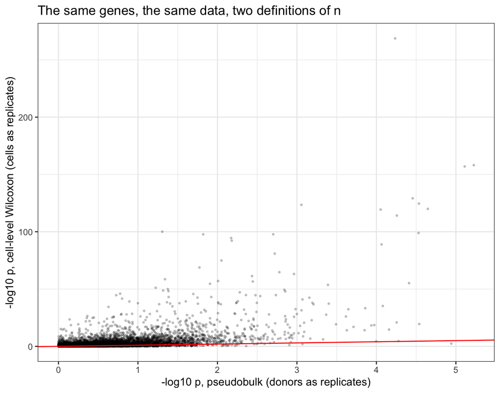

```r
compare_df <- data.frame(
  gene = shared_genes,
  cell_level = -log10(cell_level_res[shared_genes, "p_val"] + 1e-300),
  pseudobulk = -log10(deseq2_res[shared_genes, "pvalue"]))

gg <- ggplot2::ggplot(compare_df,
                      ggplot2::aes(x = pseudobulk, y = cell_level)) +
  ggplot2::geom_point(alpha = 0.2, size = 0.6) +
  ggplot2::geom_abline(slope = 1, intercept = 0, colour = "red") +
  ggplot2::labs(x = "-log10 p, pseudobulk (donors as replicates)",
                y = "-log10 p, cell-level Wilcoxon (cells as replicates)",
                title = "The same genes, the same data, two definitions of n") +
  ggplot2::theme_bw()
plot(gg)
```

> **This is not an argument that cell-level tests are always wrong.** They are the right tool for the question in the companion tutorial — what distinguishes one cluster of cells from another — where cells genuinely are the units. The error is using them for a question about donors. Mixed models that keep cells as observations while modelling donor as a random effect are a third option and a real area of method development.

# 12 How much of the variation is what you care about?

Before reading a gene list, it is worth asking how much of the expression variation in this dataset any of these variables explains. `variancePartition` answers that per gene.

```r
varpart_formula <- ~ ADNC + sex + APOE4.status + mito_fraction + n_cells

vsd_mat_top <- vsd_mat[order(apply(vsd_mat, 1, var),
                             decreasing = TRUE)[1:2000], ]

varpart_res <- variancePartition::fitExtractVarPartModel(
  vsd_mat_top, varpart_formula, metadata_pseudobulk)

head(variancePartition::sortCols(varpart_res))
```

```
##                 mito_fraction      n_cells        sex         ADNC APOE4.status
## XIST             2.357410e-06 8.907830e-06 0.99762826 6.913857e-05 5.492668e-05
## LINC00278        1.132835e-03 6.298742e-04 0.96522811 1.289118e-04 3.906695e-11
## UTY              1.926074e-03 6.611188e-04 0.96494803 1.431344e-04 2.272490e-06
## TTTY14           6.399155e-05 4.364934e-05 0.96386232 3.366183e-05 1.214654e-05
## USP9Y            3.338854e-07 3.834503e-04 0.96676392 4.188588e-05 1.140063e-05
## ENSG00000285534  1.795153e-03 5.600148e-04 0.02922989 1.005669e-02 9.834205e-03
##                   Residuals
## XIST            0.002236412
## LINC00278       0.032880270
## UTY             0.032319373
## TTTY14          0.035984229
## USP9Y           0.032799006
## ENSG00000285534 0.948524050
```

> **Fixed effects or random effects is not a formatting choice here.** The formula above declares every variable as a fixed effect, and that decision is load-bearing. Written instead as `~ (1 | sex) + (1 | ADNC) + ...`, every categorical variable becomes a random effect — and a random effect estimated from **two** levels has almost no information about its own variance, so the fitted variance component collapses to zero. Run this analysis that way and `XIST`, a gene expressed almost exclusively in females, comes back with sex explaining ~0% of its variance and residual ~100%. The result is not flagged; it just looks like a null. `variancePartition`’s own guidance is to model categorical variables with few levels as **fixed** effects and reserve random effects for variables with many levels — donor in a repeated-measures design, batch across dozens of runs.

The sanity check is right there in the output: the most variable genes in this pseudobulk are sex-chromosome and X-inactivation genes, so `sex` had better account for nearly all of their variance.

```r
sex_genes <- intersect(c("XIST", "UTY", "USP9Y", "RPS4Y1", "DDX3Y", "KDM5D"),
                       rownames(varpart_res))
varpart_res[sex_genes, ]
```

```
##                ADNC       sex APOE4.status mito_fraction      n_cells
## XIST   6.913857e-05 0.9976283 5.492668e-05  2.357410e-06 8.907830e-06
## UTY    1.431344e-04 0.9649480 2.272490e-06  1.926074e-03 6.611188e-04
## USP9Y  4.188588e-05 0.9667639 1.140063e-05  3.338854e-07 3.834503e-04
## RPS4Y1 2.264938e-03 0.9346333 6.469524e-04  3.732988e-03 6.654740e-05
## DDX3Y  3.767290e-05 0.9392883 1.533148e-04  2.794386e-05 1.588931e-03
## KDM5D  1.370248e-04 0.9641409 4.816747e-06  1.069061e-03 1.429173e-03
##          Residuals
## XIST   0.002236412
## UTY    0.032319373
## USP9Y  0.032799006
## RPS4Y1 0.058655322
## DDX3Y  0.058903844
## KDM5D  0.033219023
```

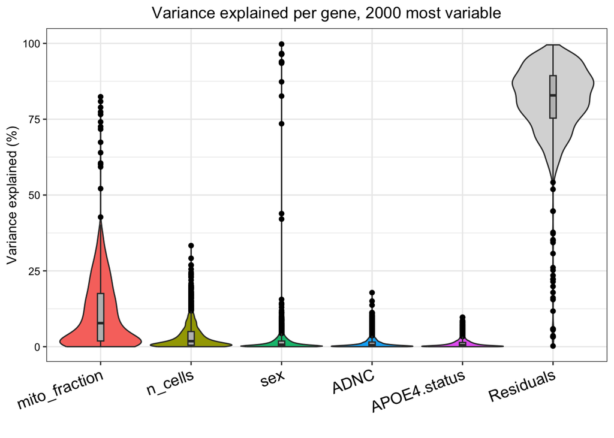

```r
gg <- variancePartition::plotVarPart(variancePartition::sortCols(varpart_res)) +
  ggplot2::ggtitle("Variance explained per gene, 2000 most variable")
plot(gg)
```

```r
round(100 * colMeans(varpart_res), 2)
```

```
##          ADNC           sex  APOE4.status mito_fraction       n_cells
##          1.22          1.98          1.03         11.00          3.55
##     Residuals
##         81.22
```

```r
round(100 * apply(varpart_res, 2, median), 2)
```

```
##          ADNC           sex  APOE4.status mito_fraction       n_cells
##          0.52          0.64          0.52          7.77          1.83
##     Residuals
##         82.86
```

Two things to read off this.

**`Residuals` is the tallest box**, at 81% on average. Most of the gene-to-gene variation between donors is not explained by any label we have, which is the honest headline and a useful calibration before reading any gene list.

**And the ordering of the rest is the finding.** Averaged over the 2,000 most variable genes: `mito_fraction` **11.0%**, `n_cells` 3.6%, `sex` 2.0%, `ADNC` **1.2%**, `APOE4.status` 1.0%. The ambient-contamination covariate explains roughly **nine times** as much variance as the disease variable this whole analysis is about. The tall spike in the `sex` column is the sanity check working — a handful of sex-chromosome genes at nearly 100%, and almost nothing else.

That is the same conclusion the mitochondrial section reached, arrived at independently and without reference to any p-value. It does not mean there is no AD signal; it means the AD signal is small relative to a technical one, which is exactly the situation where analysis choices decide the answer.

# 13 What do the genes do?

A ranked gene list is not a finding. Gene set enrichment analysis asks whether genes belonging to a known biological process sit systematically high or low in your ranking.

The ranking statistic is a choice. Ranking by shrunk log fold change asks “what changed most”; ranking by the Wald statistic asks “what changed most relative to its uncertainty”, which folds in how well each gene was measured.

```r
teststat_vec <- deseq2_res[, "stat"]
names(teststat_vec) <- rownames(deseq2_res)
teststat_vec <- teststat_vec[!is.na(teststat_vec)]
teststat_vec <- sort(teststat_vec, decreasing = TRUE)

length(teststat_vec)
```

```
## [1] 15420
```

```r
head(teststat_vec)
```

```
## ENSG00000233005       TNFRSF11B         MT-ATP6          MT-ND3 ENSG00000286044
##        5.573794        5.264627        4.528077        4.471987        4.388370
##          MT-CYB
##        4.238089
```

```r
tail(teststat_vec)
```

```
##    RNF180    ANKRD7     PRKCA     SNX11      TLN2    SUCNR1
## -3.888634 -3.899557 -3.926805 -4.043357 -4.114233 -4.267310
```

```r
sum(grepl("^ENSG", names(teststat_vec)))
```

```
## [1] 1363
```

> **Not every row name is a gene symbol.** This matrix mixes HGNC symbols with bare Ensembl IDs for features that had no symbol at annotation time — and two of them sit in the top five of the ranking. Passing `keyType = "SYMBOL"` means `gseGO()` silently drops every one of them. That is the right behaviour, but “silently” is the operative word: nothing tells you how much of your ranked list was discarded before the enrichment was computed. Count them yourself.

> **GSEA is randomized, and its p-values move between runs unless you say otherwise.** `gseGO()` takes a `seed` argument that is `FALSE` by default, so the permutation p-values shift a little every time you run it. Passing `seed = TRUE` is enough to fix that. We check that claim rather than trusting it, two chunks down.

```r
gse <- clusterProfiler::gseGO(teststat_vec,
                              ont = "BP",
                              keyType = "SYMBOL",
                              OrgDb = "org.Hs.eg.db",
                              minGSSize = 10,
                              maxGSSize = 500,
                              seed = TRUE,
                              verbose = FALSE)

gse_df <- as.data.frame(gse)
dim(gse_df)
```

```
## [1] 363  11
```

```r
head(gse_df[, c("Description", "setSize", "NES", "pvalue", "p.adjust")], 10)
```

```
##                                                      Description setSize
## GO:1903706                             regulation of hemopoiesis     305
## GO:0050804          modulation of chemical synaptic transmission     398
## GO:0099177                regulation of trans-synaptic signaling     399
## GO:0042391                      regulation of membrane potential     331
## GO:1902105               regulation of leukocyte differentiation     235
## GO:0061564                                      axon development     393
## GO:0002521                             leukocyte differentiation     451
## GO:0007610                                              behavior     488
## GO:0007409                                          axonogenesis     350
## GO:0048667 cell morphogenesis involved in neuron differentiation     468
##                  NES       pvalue     p.adjust
## GO:1903706  2.055083 1.000000e-10 1.319500e-07
## GO:0050804 -2.052259 1.000000e-10 1.319500e-07
## GO:0099177 -2.047971 1.000000e-10 1.319500e-07
## GO:0042391 -2.033357 1.000000e-10 1.319500e-07
## GO:1902105  2.072626 4.719250e-10 4.070939e-07
## GO:0061564 -1.896038 4.900457e-10 4.070939e-07
## GO:0002521  1.833663 5.443859e-10 4.070939e-07
## GO:0007610 -1.829607 6.170427e-10 4.070939e-07
## GO:0007409 -1.918617 8.652172e-10 5.074018e-07
## GO:0048667 -1.832678 1.700134e-09 8.973308e-07
```

```r
gse_again <- clusterProfiler::gseGO(teststat_vec,
                                    ont = "BP",
                                    keyType = "SYMBOL",
                                    OrgDb = "org.Hs.eg.db",
                                    minGSSize = 10,
                                    maxGSSize = 500,
                                    seed = TRUE,
                                    verbose = FALSE)

identical(as.data.frame(gse_again)$pvalue, gse_df$pvalue)
```

```
## [1] TRUE
```

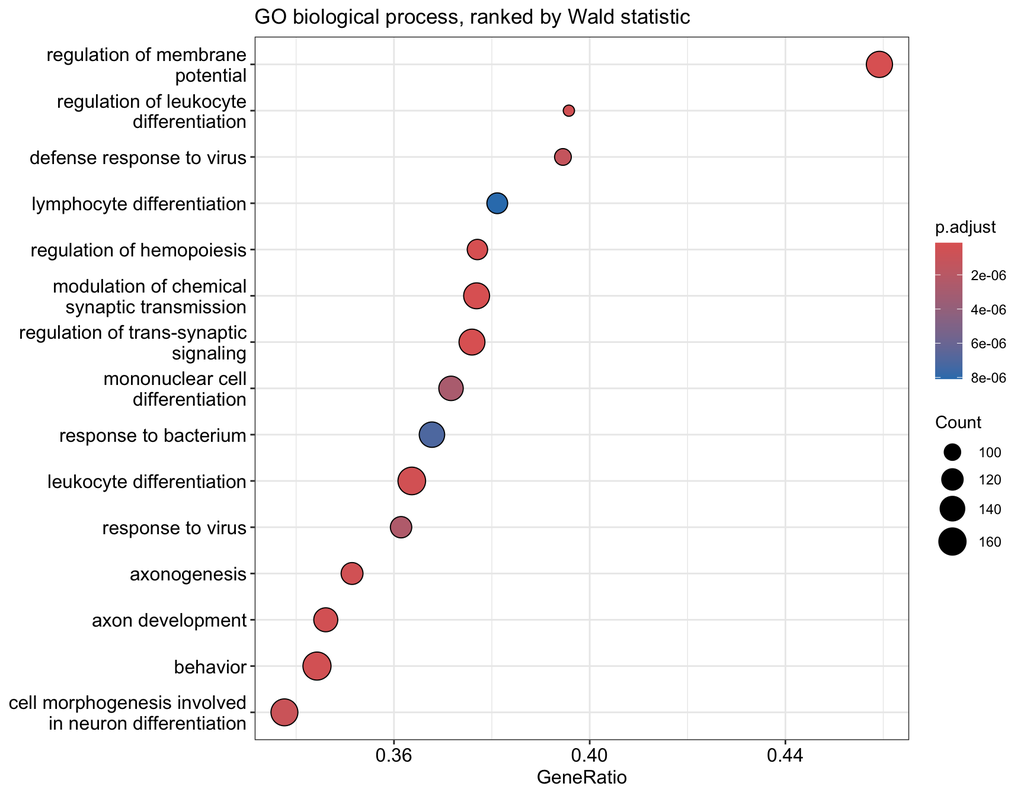

```r
gg <- enrichplot::dotplot(gse, showCategory = 15) +
  ggplot2::ggtitle("GO biological process, ranked by Wald statistic")
plot(gg)
```

A positive normalized enrichment score means the set sits toward the AD end of the ranking; negative means the non-AD end.

Read the top ten and notice what is in it. `regulation of hemopoiesis` and `regulation of leukocyte differentiation` come out positive — those are myeloid processes and microglia are myeloid cells, so that is coherent. But `modulation of chemical synaptic transmission`, `regulation of trans-synaptic signaling`, `axon development`, `axonogenesis` and `cell morphogenesis involved in neuron differentiation` are all strongly **negative**, and this dataset contains nothing but microglia.

> **Neuronal gene sets in a purely microglial analysis are a contamination readout, not a discovery.** Microglia sit in a dense neuropil; ambient RNA in cortical snRNA-seq is dominated by neuronal transcripts. Their coordinated movement across the ranking tells you how much neuronal soup each group’s libraries carried. It is the same phenomenon as the mitochondrial block above, arriving through a different door — and GSEA is *especially* prone to surfacing it, because ambient RNA moves whole functional modules together, which is exactly the pattern GSEA is built to detect.

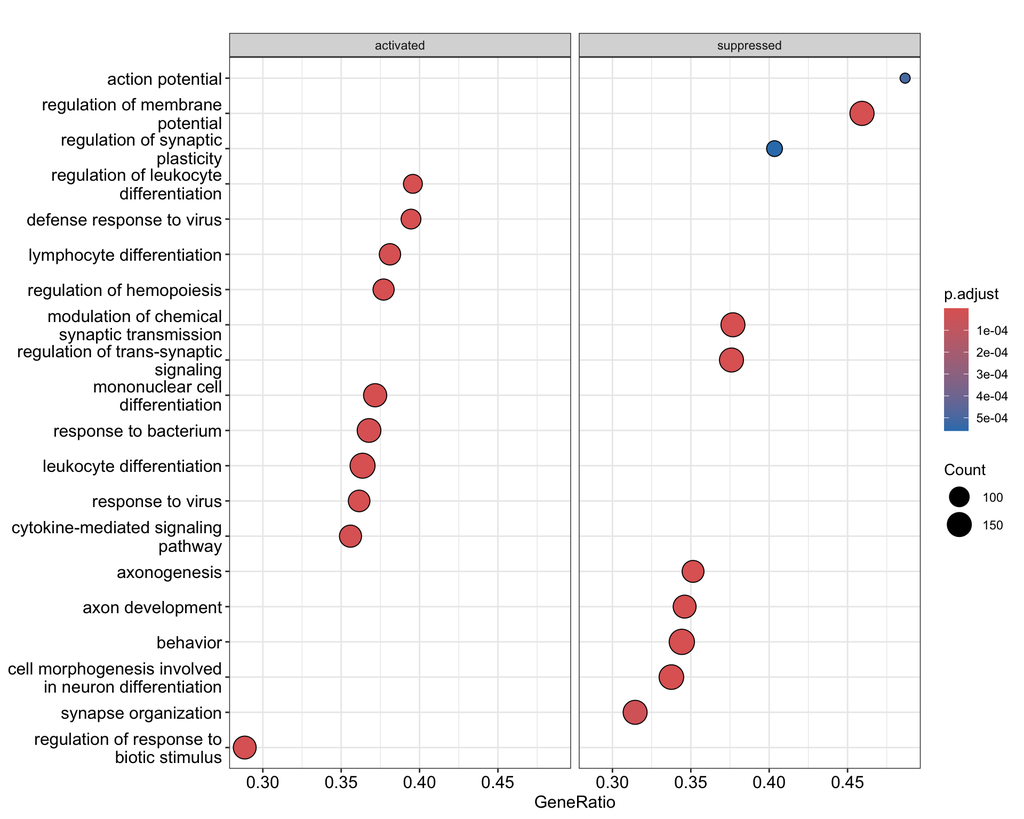

```r
gg <- enrichplot::dotplot(gse, showCategory = 10, split = ".sign") +
  ggplot2::facet_grid(. ~ .sign)
plot(gg)
```

> **GSEA is testing thousands of overlapping gene sets.** GO terms are nested — a parent term contains its children — so a single real signal produces a column of related, individually “significant” rows. Read the top of the table as one finding with several names, not as several findings.